# Linear HW#6

Tonghao Zhang

2016/11/13

## 7.22

There is one possible explaination of this phenanimon, multicolinearity among the predictor variables. Because of multicolinearity, two variable can fit the data fairly well while other coefficients are not statsistically significant. But multicolinearity does not inhibit us from obtaining precise estimate value. With more predictor included, the predictions will be more precise.

# 7.24

#### a)

Y = 50.775 + 4.425 $X_1$

#### b)

```
## [1] 0
```

The coefficent $\beta_1$ from part a is identical to that of 6.5.

#### c)

```
## Analysis of Variance Table
##
## Response: Y
##           Df  Sum Sq Mean Sq F value    Pr(>F)
## X1         1 1566.45 1566.45  54.751 3.356e-06 ***
## Residuals 14  400.55   28.61
## ---
## Signif. codes:  0 '***' 0.001 '**' 0.01 '*' 0.05 '.' 0.1 ' ' 1
```

```
## Analysis of Variance Table
##
## Response: Y
##           Df  Sum Sq Mean Sq F value    Pr(>F)
## X2         1  306.25  306.25  42.219 2.011e-05 ***
## X1         1 1566.45 1566.45 215.947 1.778e-09 ***
## Residuals 13   94.30    7.25
## ---
## Signif. codes:  0 '***' 0.001 '**' 0.01 '*' 0.05 '.' 0.1 ' ' 1
```

Yes, SSR($X_1$) equals to SSR($X_1|X_2$).

#### d)

The correlation between $X1$ and $X_2$ is 0, so the infomation in these two variable does not overlap, the two models from 6.5 and 7.24 produce the same $\beta_1$, SSR($X_1$) equals to SSR($X_1|X_2$).

## Problem 3

#### a)

```
##
## Call:
## lm(formula = strength ~ as.factor(group), data = data3)
##
## Coefficients:
##       (Intercept)  as.factor(group)2  as.factor(group)3
##            17.633              3.633             13.600
## as.factor(group)4  as.factor(group)5  as.factor(group)6
##           -11.767             -6.067             -2.700
```

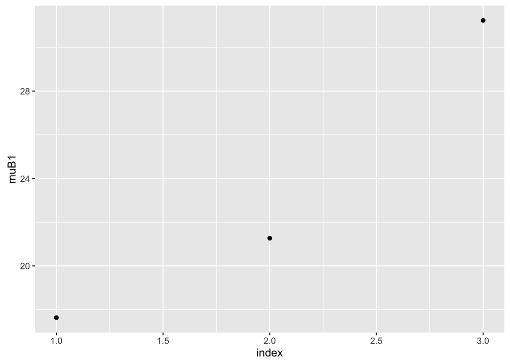

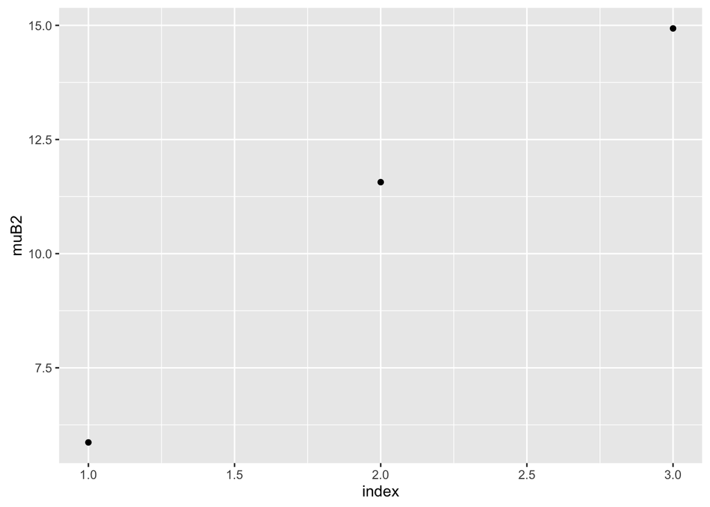

$\beta_0$ = 17.633, $\beta_1$ = 3.633, $\beta_2$ = 13.600, $\beta_3$ = -11.767, $\beta_4$ = -6.067, $\beta_5$ = -2.700.

#### b)

```
##
## Call:
## lm(formula = strength ~ A + as.factor(B), data = data3)
##
## Coefficients:
##   (Intercept)              A  as.factor(B)2
##        12.044          5.667        -12.589
```

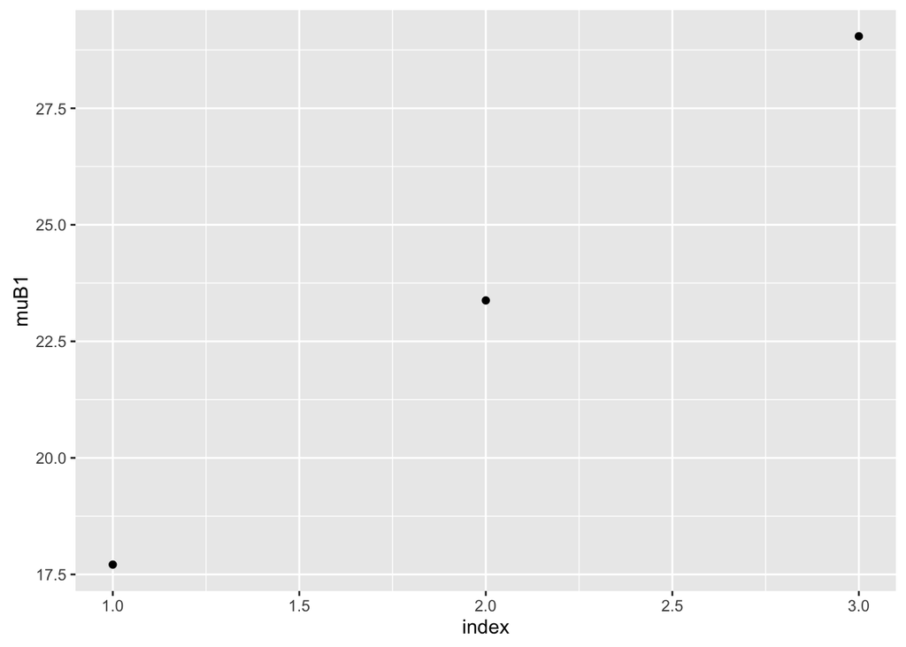

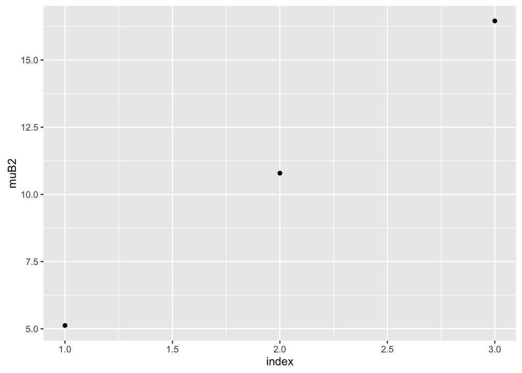

#### c)

```
##
## Call:
## lm(formula = strength ~ as.factor(A) + B, data = data3)
##
## Coefficients:
##   (Intercept)  as.factor(A)2  as.factor(A)3              B
##        30.633          4.667         11.333        -12.589
```

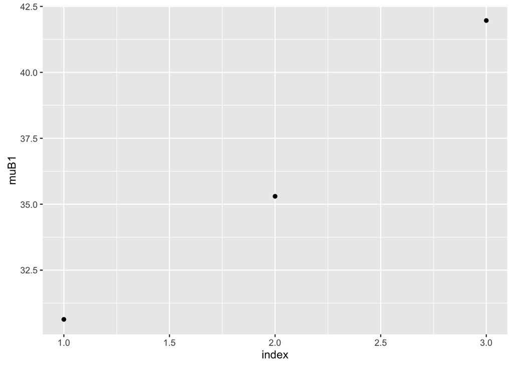

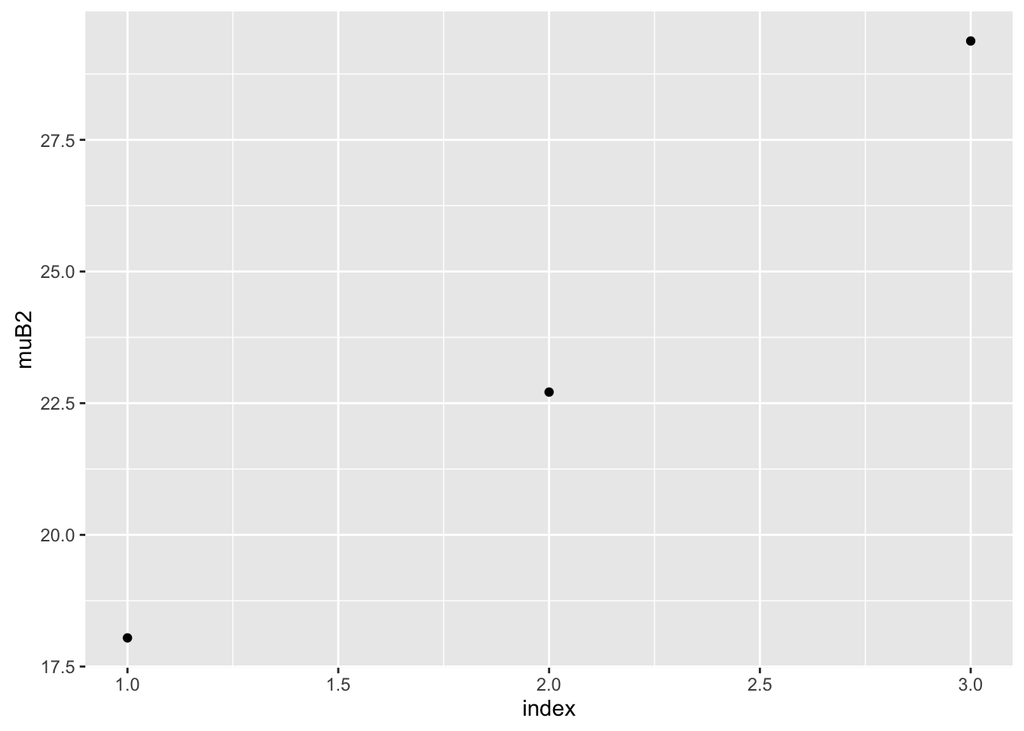

## 8.6

```
##
## Call:
## lm(formula = Y ~ Xstar + I(Xstar^2), data = data8.6)
##
## Coefficients:
## (Intercept)        Xstar   I(Xstar^2)
##     21.0942       1.1374      -0.1184
```

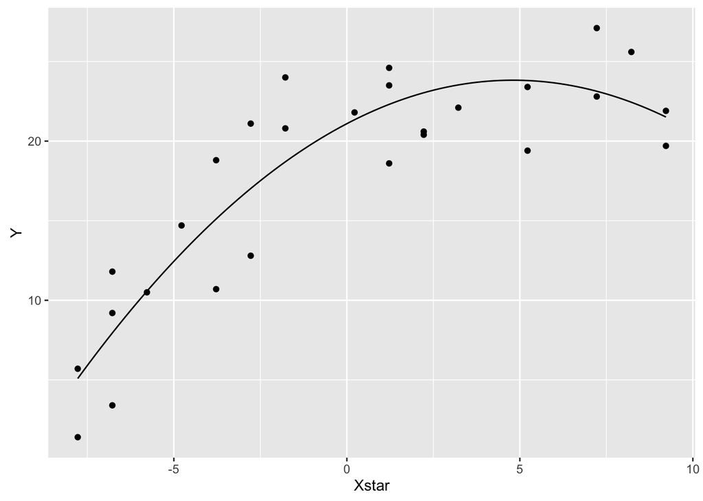

```
## Analysis of Variance Table
##
## Response: Y
##            Df Sum Sq Mean Sq F value    Pr(>F)
## Xstar       1 793.28  793.28  79.813 4.236e-09 ***
## I(Xstar^2)  1 252.99  252.99  25.453 3.708e-05 ***
## Residuals  24 238.54    9.94
## ---
## Signif. codes:  0 '***' 0.001 '**' 0.01 '*' 0.05 '.' 0.1 ' ' 1
```

The plot indicates it’s a good fit.

$R^2 = \frac{SSR}{SSTO} = \frac{793.28+252.99}{793.28+252.99+238.54}$ = 0.814

#### b)

```
## Analysis of Variance Table
##
## Model 1: Y ~ Xstar + I(Xstar^2)
## Model 2: Y ~ as.factor(Xstar)
##   Res.Df    RSS Df Sum of Sq      F Pr(>F)
## 1     24 238.54
## 2     12 158.69 12    79.847 0.5032 0.8758
```

Lack of fit test here, $H_0$ : there is such a regression relationship, $H_A$: no such regression relationship.

#### c)

```
## $fit
##        fit       lwr      upr
## 1 10.57021  7.299373 13.84104
## 2 20.13792 16.977130 23.29872
## 3 23.78558 20.749504 26.82165
##
## $se.fit
##         1         2         3
## 0.9238420 0.8927612 0.8575340
##
## $df
## [1] 24
##
## $residual.scale
## [1] 3.15265
```

```
##         1         2         3         1         2         3
##  7.094528 16.779176 20.559362 14.045886 23.496670 27.011792
```

Confidence interval from Bonferroni method is better. The possiblity of all mean at 10, 15, 20 to fall into confidence interval above simutaneously is more than 99%.

#### d)

```
## $fit
##        fit      lwr      upr
## 1 20.13792 10.97342 29.30242
##
## $se.fit
## [1] 0.8927612
##
## $df
## [1] 24
##
## $residual.scale
## [1] 3.15265
```

When sample a new female with steriod level of 15, the possiblity of the outcome to fall into confidence level above is more than 99%.

#### e)

```
## Analysis of Variance Table
##
## Response: Y
##            Df Sum Sq Mean Sq F value    Pr(>F)
## Xstar       1 793.28  793.28  79.813 4.236e-09 ***
## I(Xstar^2)  1 252.99  252.99  25.453 3.708e-05 ***
## Residuals  24 238.54    9.94
## ---
## Signif. codes:  0 '***' 0.001 '**' 0.01 '*' 0.05 '.' 0.1 ' ' 1
```

Full model: $Y$ ~ $X+X^2$, reduced model: $Y$ ~ $X$.

```
##
## Call:
## lm(formula = Y ~ X + I(X^2), data = data8.6)
##
## Coefficients:
## (Intercept)            X       I(X^2)
##    -26.3254       4.8736      -0.1184
```

```
##
## Call:
## lm(formula = Y ~ Xstar + I(Xstar^2), data = data8.6)
##
## Coefficients:
## (Intercept)        Xstar   I(Xstar^2)
##     21.0942       1.1374      -0.1184
```

```
## [1] 15.77778
```

$b_0$ = -26.325, $b_1$ = 4.8736, $b_2$ = -0.1184

## 8.10

#### a)

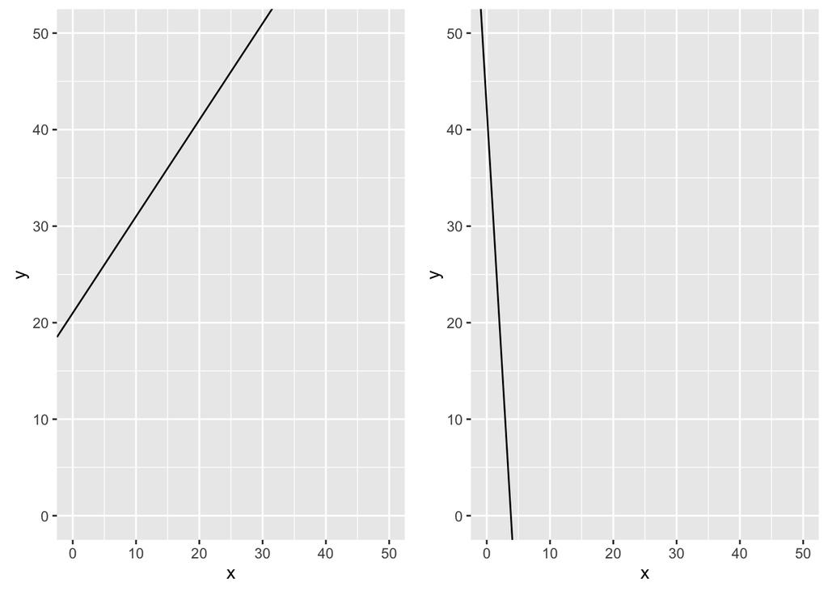

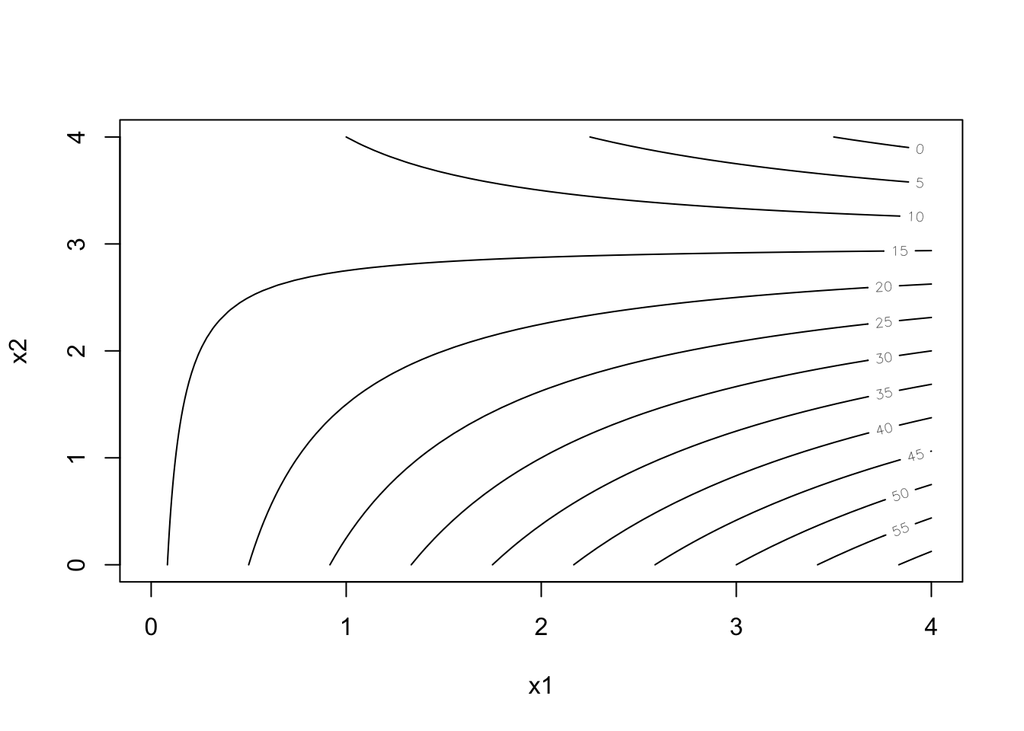

In additive model, the contours should be straight lines. So this model is not an additive one.